# Inspect CO2 emissions 04-02-20

## R Markdown

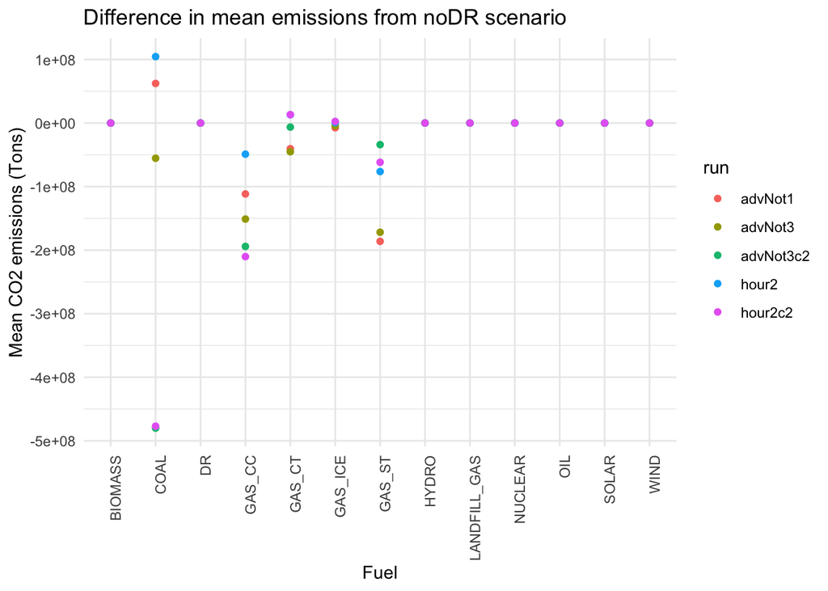

We have observed that advNot1 has emissions that are somewhat lower than noDR, and advnot3c2 has emissions that are even lower. Here, we can see that in the case of advNot1, that reduction comes from lower use of gas generators, though use of coal is higher. In the case of advNot3c2, a reduction in coal emissions drives lower emissions. Why does coal use differ so much between the scenarios? And why does advNot3c2 change coal usage so substantially?

hour2 has very similar total emissions to noDR, but looking more closely it shares more with advNot1; higher coal emissions, lower (generally) gas emissions. hour2c2 seems to tract advNot3c2 relatively well. Lets look at these pulled apart a bit in groups . (high cost), (advNot3)

What would happen if, instead of looking at the difference in mean emissions, we looked at the mean difference? Are scenarios individually similar?

What can looking at the supply curve tell us?

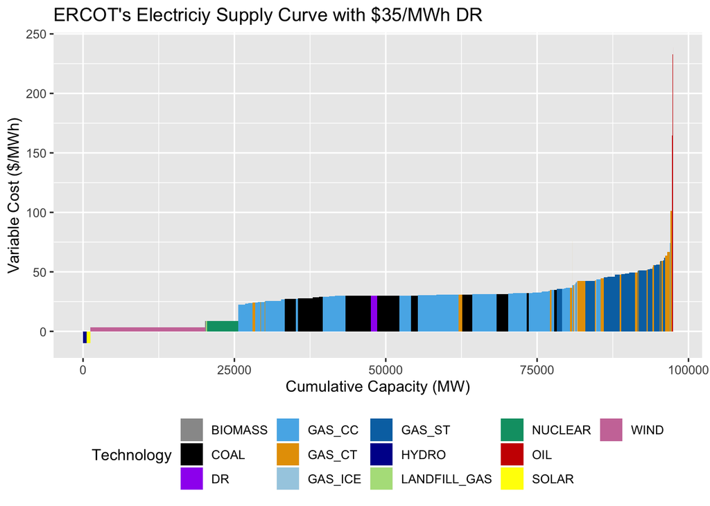

When DR is $70/MWh, this is what the supply curve looks like:

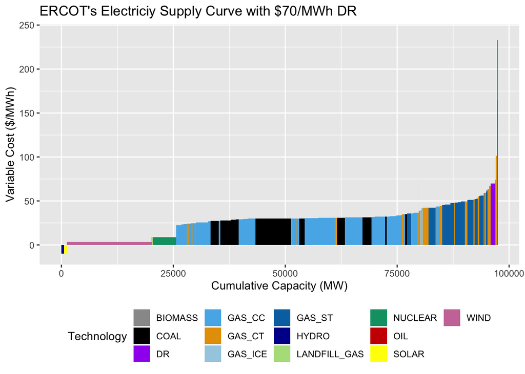

When DR requires an advance dispatch (ie. advNot3 cases), it can displace coal because even in scenarios where coal would have been more economical, DR is already operating and pushes out more expensive coal. In fact, it leads to a reduction in the use of almost *everything* else (nothing appears to increase meaningfully).

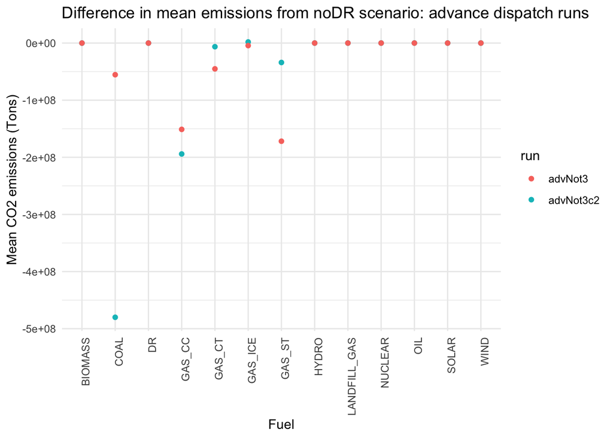

[figure not shown]

In fact, hour2c2 seems to have more in common with advance dispatch scenarios… Compared to cheaper hour2, it results in a much greater reduction in emissions, which is surprising. This reduction is driven mostly by a large decrease in emissions from Coal as well as Gas_CC (and a bit from Gas_ST) plants. All three of these are slow generators. (Gas_ct, gas_ice, and oil are the emitting fast generators).

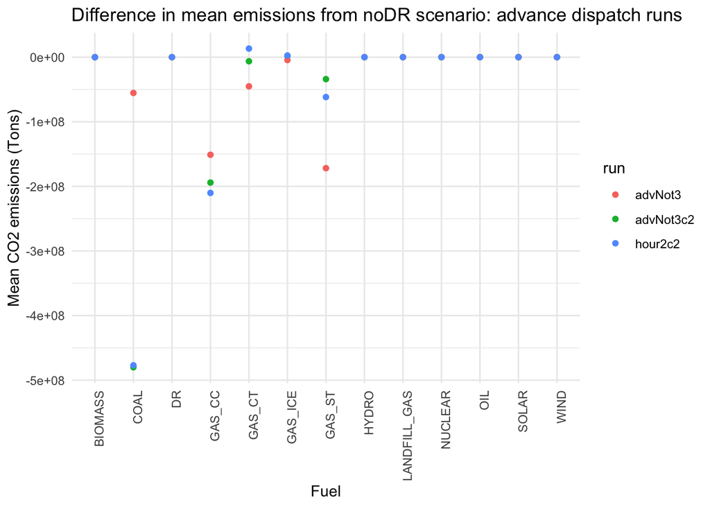

So now we know how infrequently-dispatched, expensive DR reduces emissions - by reducing the usage of other emitting generators. But there ar emany remaining questions

1. why does advNot3c2 reduce coal usage more than advNot3?
2. why does hour2c2 reduce coal and gas_cc usage while hour2 increases coal usage/emissions?

In both of these cases, the more expensive version of DR reduces the use of cheaper, baseload units MORE. Why? brainstorm – * supply curve does not take into account startup costs, which may ultimately shift DR down in the supply curve for short dispatches. * though that would not really be enough to create this effect.

[figure not shown]